# Глава_11_Экзамен

Технический специалист работает на ПК с ОС Windows 10, который периодически зависает после обновления драйвера. Служба восстановления системы была выключена. Какой вариант можно использовать в этом случае без потери данных или приложений?

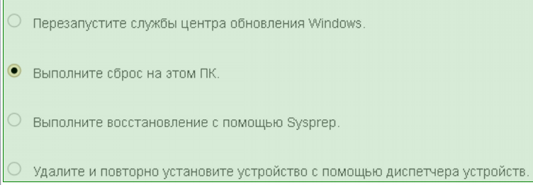

Компания внедряет беспроводную сеть и использует беспроводные устройства в корпоративной среде. Какие методы аутентификации на сервере компания должна предусмотреть в рамках проекта беспроводной сети? (Выберите два варианта.)

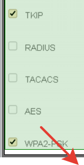

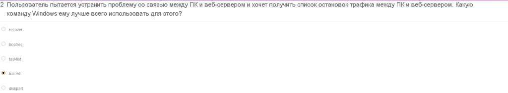

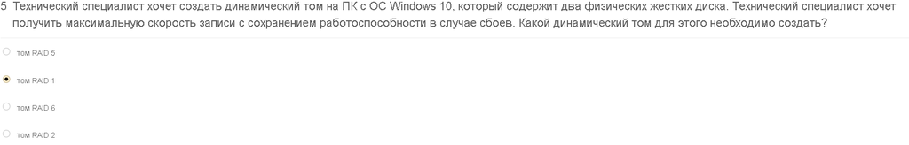

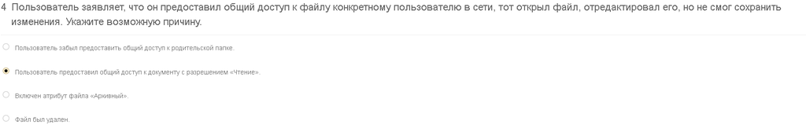

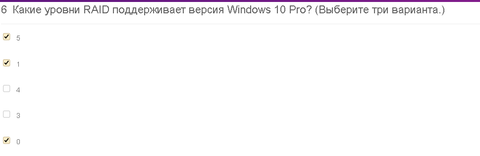

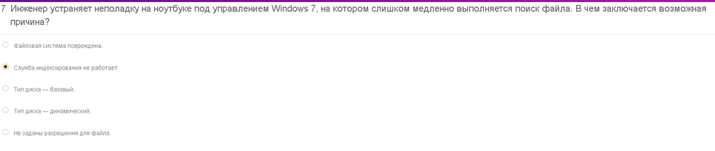

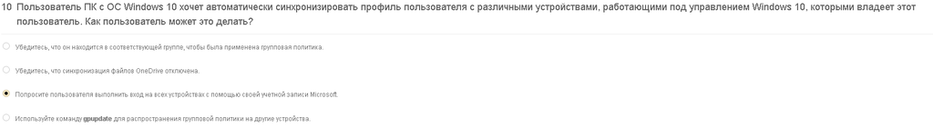

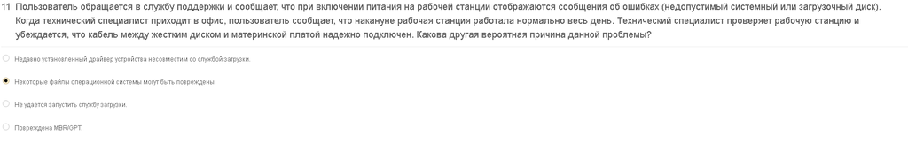

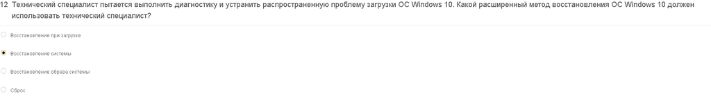

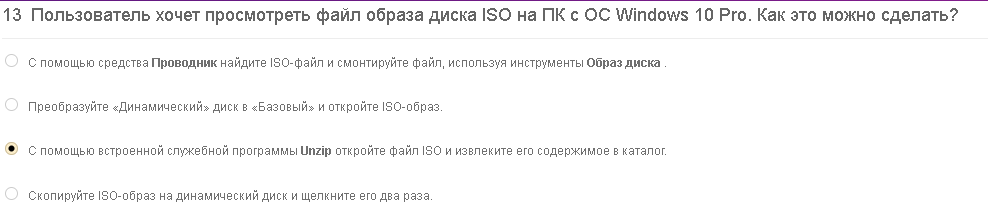

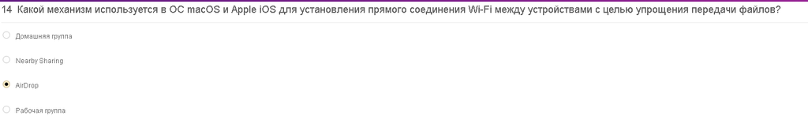

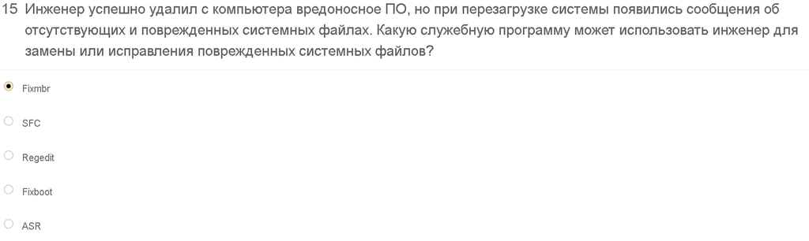

[8 more figures not shown]

IT Essentials (Версия 7.00) - Курс IT Essentials 7.0, экзамен по главе 11 Дата сдачи экзамена: 08/19/2021 01:51 PM GMT+0300 Знания в конкретной области - стандартный балл Макс. кол-во баллов: 38

Заработанные баллы: 20

Процентное отношение: 52,6%

На основании ваших ответов на вопросы экзамена вы получили следующие рекомендации:

Индивидуальная обратная связь Обратная связь по теме Обратите внимание, что по некоторым вопросам рекомендации могут быть недоступны.

Программное обеспечение. Windows. Системы Макс. кол-во баллов: 9

Заработанные баллы: 4

Процентное отношение: 44,4%

Программное обеспечение. Windows. Интерфейс командной строки Макс. кол-во баллов: 6

Заработанные баллы: 3

Процентное отношение: 50,0%

Программное обеспечение. Windows. Панели управления Макс. кол-во баллов: 7

Заработанные баллы: 3

Процентное отношение: 42,9%

Программное обеспечение. Windows. Возможности подключения Макс. кол-во баллов: 7

Заработанные баллы: 5

Процентное отношение: 71,4%

Программное обеспечение. Windows. Управление Макс. кол-во баллов: 9

Заработанные баллы: 5

Процентное отношение: 55,6%

Программное обеспечение. Windows. Служебные программы и инструменты Макс. кол-во баллов: 0

Заработанные баллы: 0

Процентное отношение: 0,0%

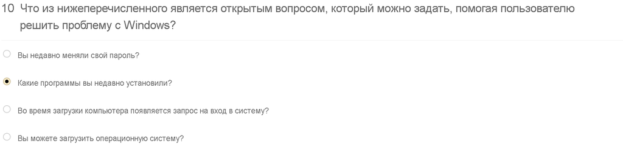

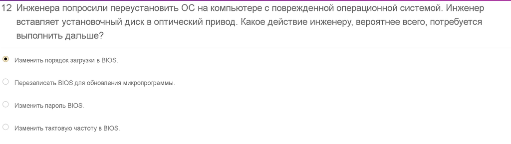

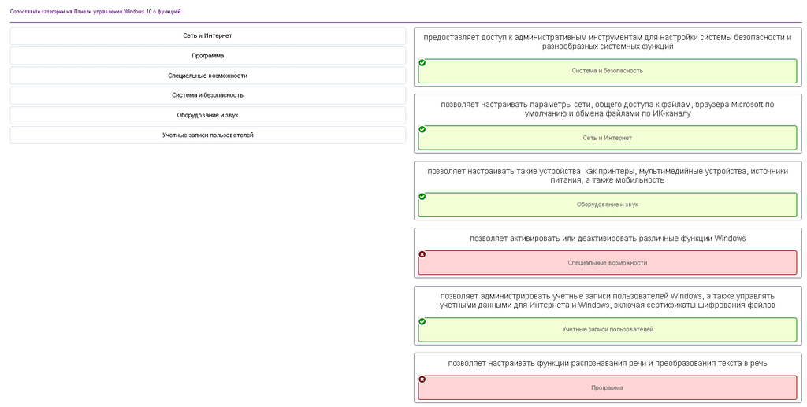

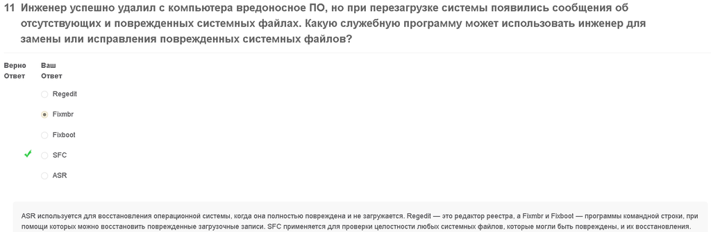

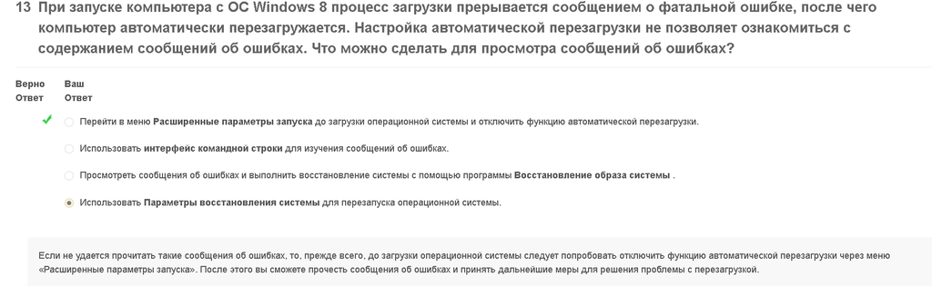

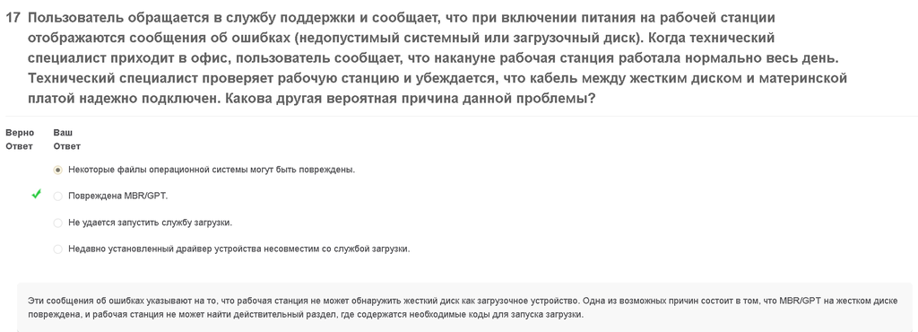

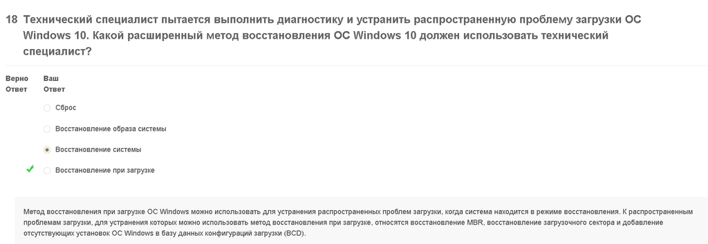

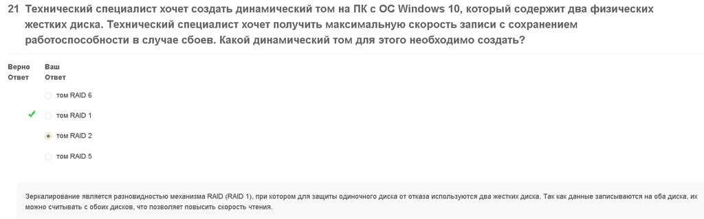

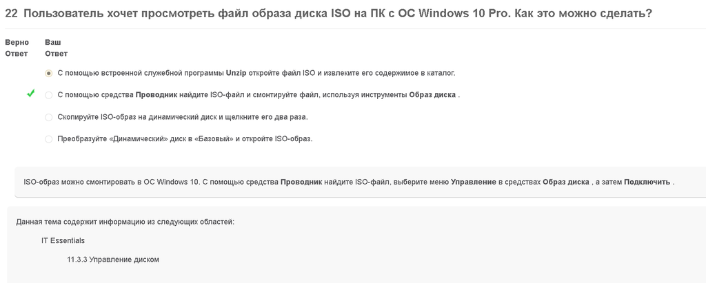

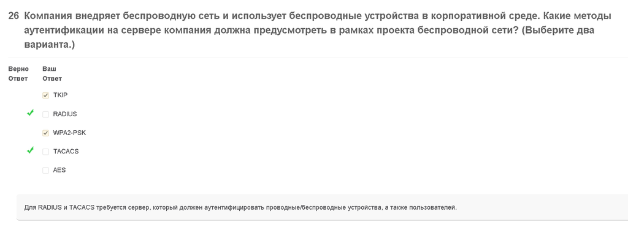

ИТ-специалист обращается в службу поддержки и сообщает о следующей ситуации. «Я добавил новый ПК в локальную сеть. Я могу отправлять эхо-запросы на другие устройства в своей локальной сети, но не на удаленные устройства.» Что ему может посоветовать служба поддержки?

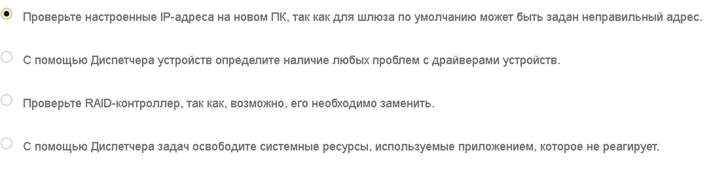

Для создания файла образа ОС Windows на одной из рабочих станций, работающих под управлением Windows 10, технический специалист использует средство Microsoft «Система обслуживания образов развертывания и управления ими» (DISM). Когда технический специалист пытается клонировать другую рабочую станцию с помощью файла образа, то по окончании процедуры эта станция сообщает о проблемах связи по сети. Какова возможная причина этой проблемы?

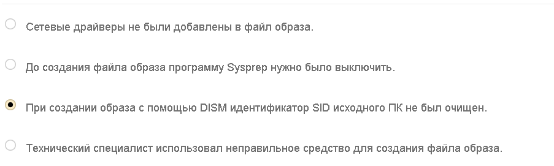

Технический специалист хочет просматривать все процессы, выполняемые для активного пользователя на ПК с ОС Windows 10. Какой вариант для этого необходимо выбрать в диспетчере задач Windows?

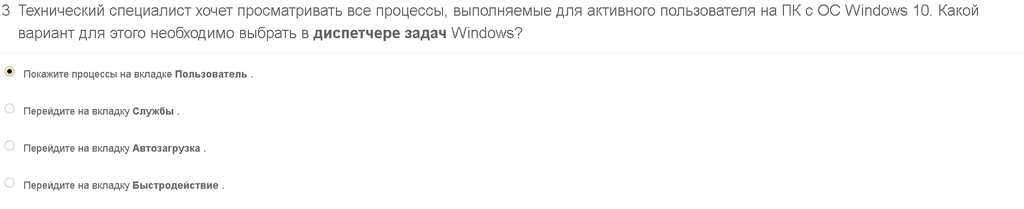

Технический специалист выполняет диагностику ПК с ОС Windows 10, где зависло окно Internet Explorer. Какую команду ему можно выполнить с правами администратора в командной строке, чтобы завершить зависший процесс Internet Explorer?